# Project 4 : A report on the expenses of the canton of Vaud

Chart Make Over project

Valentin Monney

2021-03-19

# Introduction

The goal of the last sub-project of the course is to reproduce a pie chart on the expenses of the state of Vaud, from a given picture. Here is the picture in question:

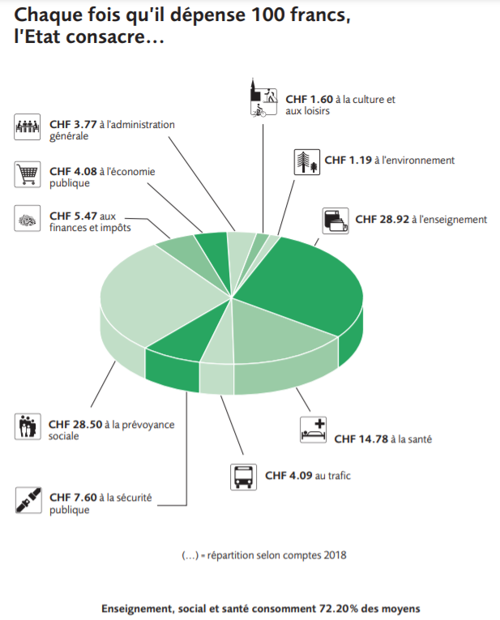

Let’s go ! [^1]

# Part 1 : Data Creation and Pie Chart Reproduction

For the first pie chart, we will try to plot it without much details. We will still try to keep the same order and the same colors.

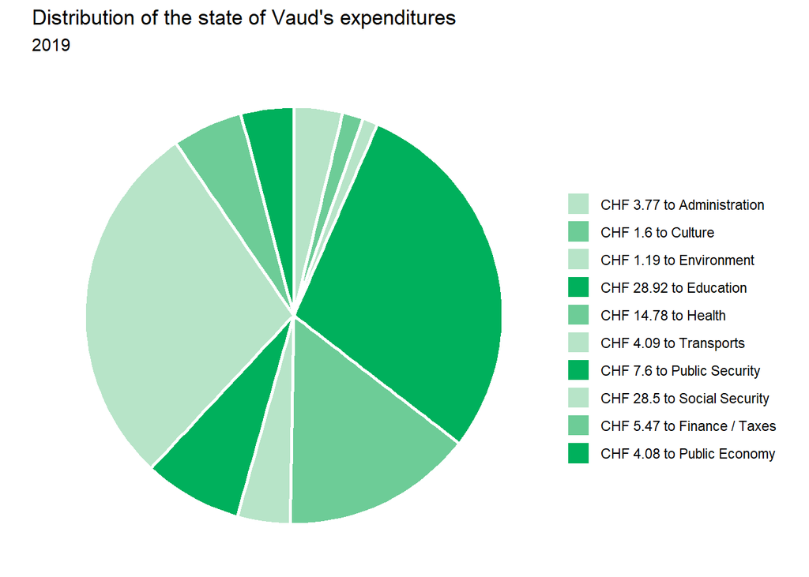

# Part 2: Customized Pie Chart

The colors chosen for the previous pie chart are not optimal. Indeed, it is difficult to associate the text with the corresponding parts. Let’s try to find a more readable color palette. We will also try to highlight the fact that “Education, social, and health accounts for 72.20% of the spending” without adding text.

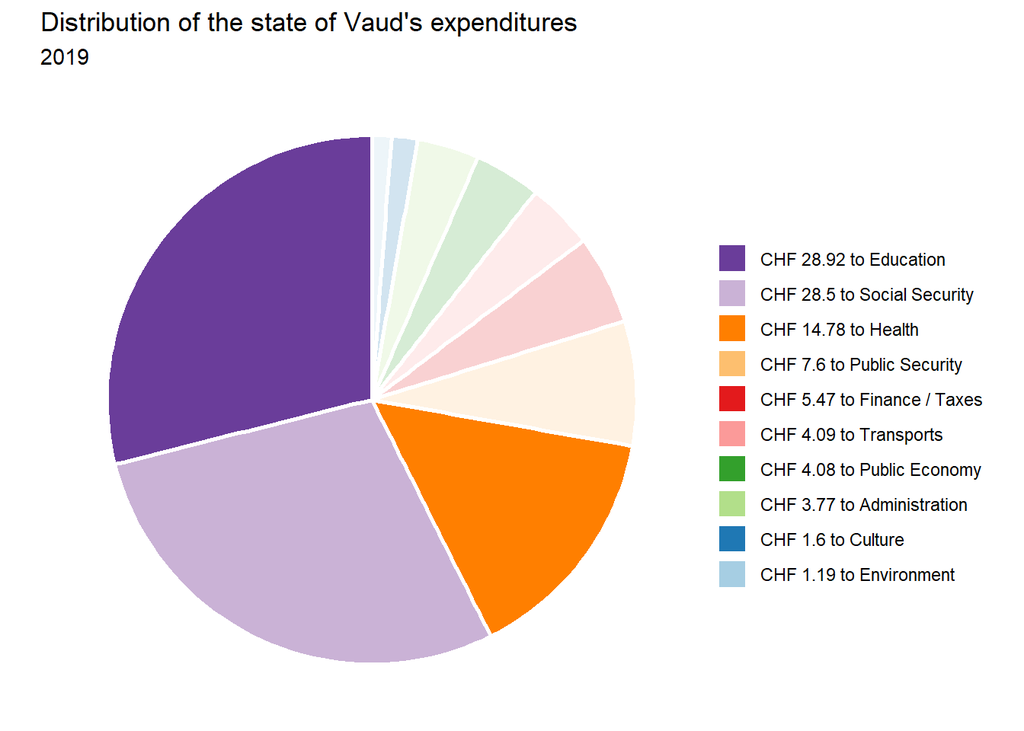

# Part 3: Alternatives to Pie Chart

As you might know, the pie chart visualization is a controversial tool for data visualization because of its limitations. First of all, it is not trivial to do a decent pie chart in R and requires a lot of code, especially if you want to place the labels in the chart.

Moreover it is difficult to compare the different parts of the pie chart without adding annotations on the graph. For example, what is the largest share between administration and public economy ? Without the amount displayed in the legend, it is very difficult to know.

Fortunately there are other types of visualization available for categorical data, and we will look at those below.

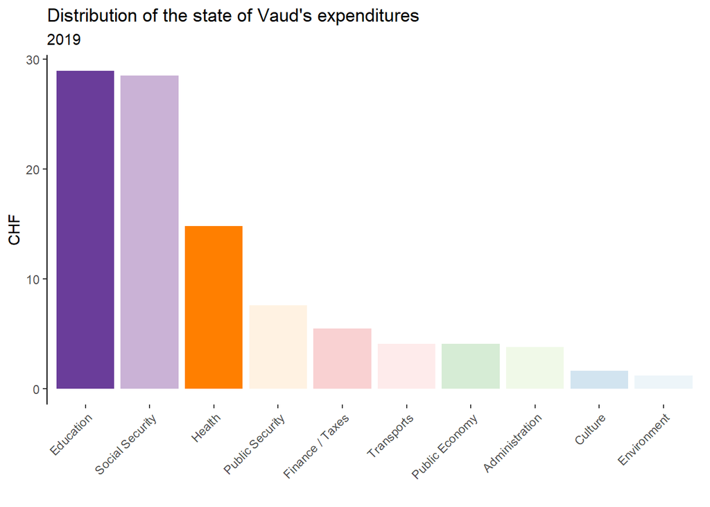

Bar charts provide a much more direct and clearer view of the different levels, even when you have 10 or more categories. It is also easier to place labels. Furthermore, we don’t need to add a legend. This is my favorite way of visualizing this data.

Another possibility is to use a stacked bar chart.

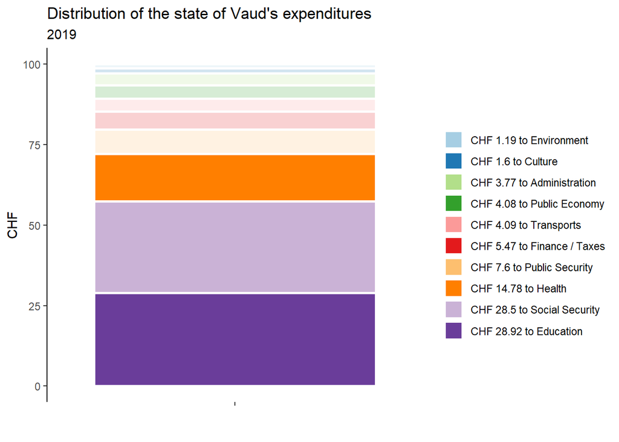

Here, the stacked bar chart does not provide more information than the pie chart. It is more of a matter of taste.

# Part 4: Analysis of State’s Spendings between 2017 and 2019

Since we have the data from the previous 2 years, let’s do an analysis of the changes that have taken place.

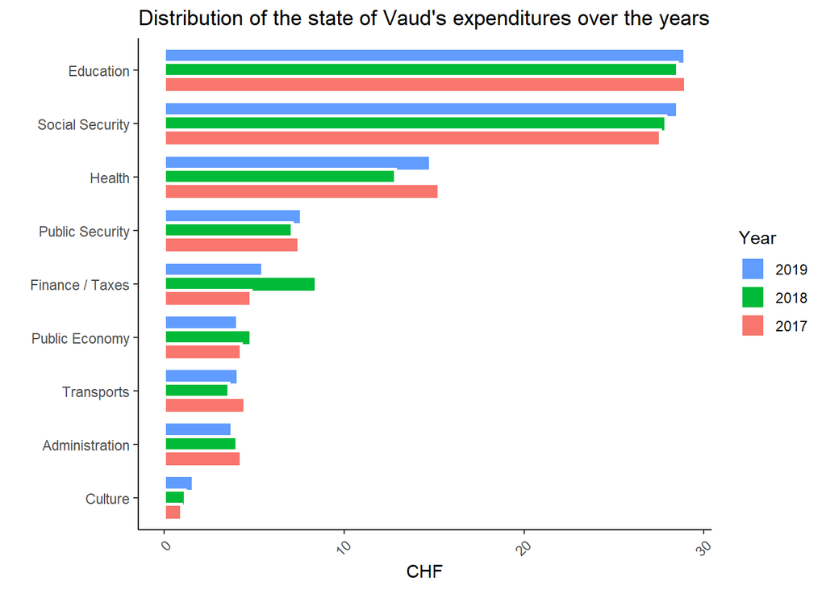

**Results:**

According to the graph, the percentage of revenue allocated to culture and social security has always increased between 2017 and 2019. Conversely, the percentage of revenue allocated to administration has decreased. In 2018, the share of spending allocated to Finance / Taxes was much higher than the other two years. It would be interesting to know what happened in 2018.

[^1]: *For the sake of consistency and because the report is in English, I will write the different expense items in English.*